# 5: Dimensionality reduction techniques

## Analysis

This week topic is Dimensionality reduction techniques.

### Summary of the data

```r
# Libraries
library(tidyverse)
library(rstatix)
library(ggpubr)
library(MASS)
```

```r
library(ggplot2)
library(GGally)
library(reshape2)
library(tidyr)
library(corrplot)
library(factoextra)
library(FactoMineR)
# Let's try new package for producion of summary table and plot of the data
library(modelsummary)
# head of data
head(human_data.subset)
```

```
##               Edu2.FM   Labo.FM Edu.Exp Life.Exp   GNI Mat.Mor Ado.Birth
## Afghanistan 0.1987421 0.1979866     9.3     60.4  1885     400      86.8
## Albania     0.6854962 0.9306030    11.8     77.8  9943      21      15.3
## Algeria     0.2105263 0.8612903    14.0     74.8 13054      89      10.0
## Arab States 0.3081009 0.7289916    12.0     70.6 15722     155      45.4
## Argentina   0.6333333 0.9774306    17.9     76.3 22050      69      54.4
## Armenia     0.7465565 0.9894737    12.3     74.7  8124      29      27.1
##             Parli.F
## Afghanistan    27.6
## Albania        20.7
## Algeria        25.7
## Arab States    14.0
## Argentina      36.8
## Armenia        10.7
```

```r
# Summary of the Human Data
datasummary_skim(human_data.subset)
```

|  | Unique (#) | Missing (%) | Mean | SD | Min | Median | Max |  |
| --- | --- | --- | --- | --- | --- | --- | --- | --- |
| Edu2.FM | 155 | 0 | 0.7 | 0.2 | 0.2 | 0.8 | 1.0 |  |
| Labo.FM | 151 | 0 | 0.9 | 0.2 | 0.2 | 0.9 | 1.5 |  |
| Edu.Exp | 85 | 0 | 13.2 | 2.8 | 5.4 | 13.5 | 20.2 |  |
| Life.Exp | 112 | 0 | 71.7 | 8.3 | 49.0 | 74.2 | 83.5 |  |
| GNI | 155 | 0 | 17651.1 | 18539.2 | 581.0 | 12040.0 | 123124.0 |  |
| Mat.Mor | 88 | 0 | 149.2 | 211.8 | 1.0 | 49.0 | 1100.0 |  |
| Ado.Birth | 139 | 0 | 47.1 | 41.1 | 0.6 | 33.6 | 204.8 |  |
| Parli.F | 123 | 0 | 20.7 | 11.4 | 0.0 | 19.3 | 57.5 |  |

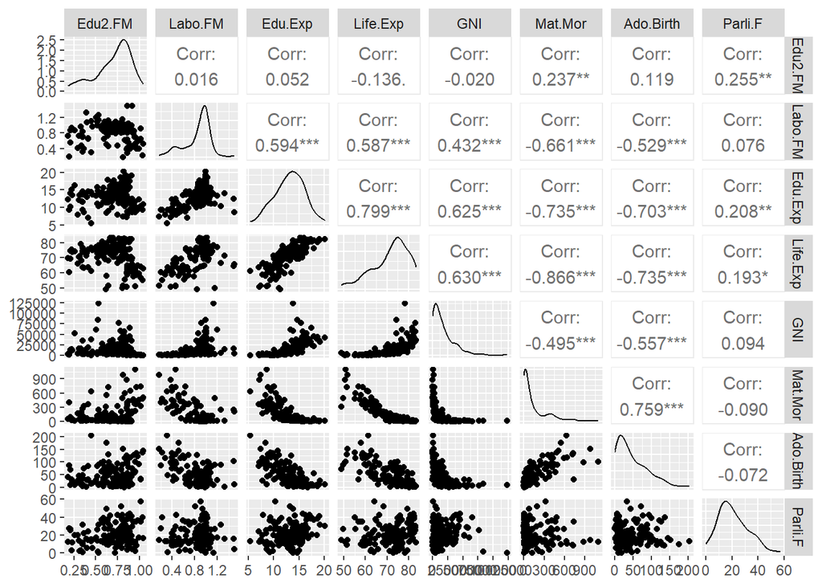

```r
# Summary plot
## Scatterplot
ggpairs(human_data.subset, mapping = aes(), lower =list(combo = wrap("facethist", bins = 20)))
```

```r
# Correlation plot
datasummary_correlation(human_data.subset)
```

|  | Edu2.FM | Labo.FM | Edu.Exp | Life.Exp | GNI | Mat.Mor | Ado.Birth | Parli.F |
| --- | --- | --- | --- | --- | --- | --- | --- | --- |
| Edu2.FM | 1 | . | . | . | . | . | . | . |
| Labo.FM | .02 | 1 | . | . | . | . | . | . |
| Edu.Exp | .05 | .59 | 1 | . | . | . | . | . |
| Life.Exp | −.14 | .59 | .80 | 1 | . | . | . | . |
| GNI | −.02 | .43 | .62 | .63 | 1 | . | . | . |
| Mat.Mor | .24 | −.66 | −.74 | −.87 | −.50 | 1 | . | . |
| Ado.Birth | .12 | −.53 | −.70 | −.74 | −.56 | .76 | 1 | . |
| Parli.F | .26 | .08 | .21 | .19 | .09 | −.09 | −.07 | 1 |

There are differences between variables in value scale and distributions. E.g. our new variables has information combined from to column showing ratios, GNI has highest values and highest range. Overall, values difference from 0 to 123124 meaning that some sort of scaling and normalization should be done to make different variables to be comparable.

### PCA raw data

Principal component analysis (PCA) is a popular technique for analyzing large datasets containing a high number of dimensions/features per observation, increasing the interpretability of data while preserving the maximum amount of information, and enabling the visualization of multidimensional data. Formally, PCA is a statistical technique for reducing the dimensionality of a dataset. This is accomplished by linearly transforming the data into a new coordinate system where (most of) the variation in the data can be described with fewer dimensions than the initial data. (wikipedia)

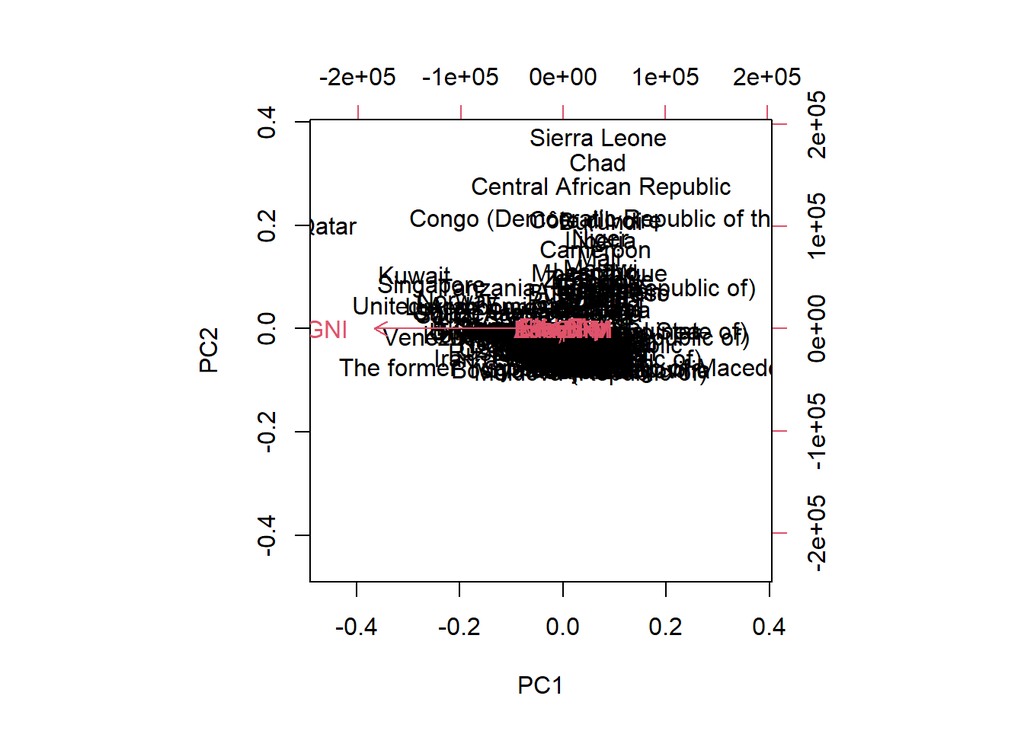

```r
# perform principal component analysis (with the SVD method)
pca_human <- prcomp(human_data.subset)

# draw a biplot of the principal component representation and the original variables
biplot(pca_human, choices = 1:2)
```

From the plot, we can’t see much or use it like that for good interpretation. As far, we can say that GNI seems to influence PC1.

### PCA standardized data

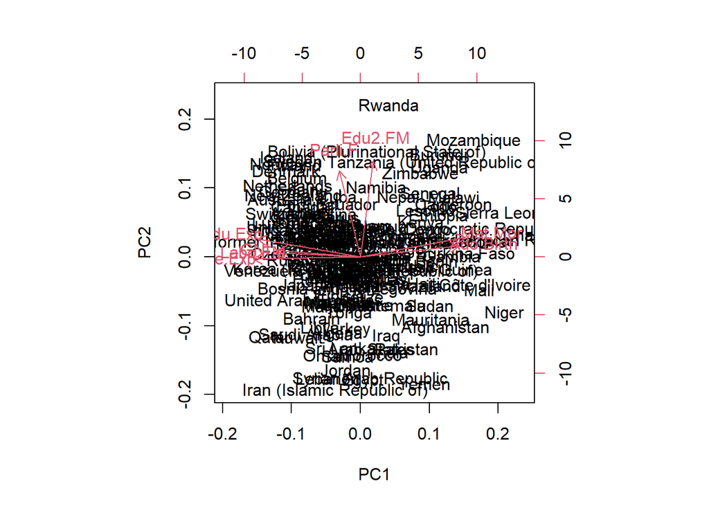

```r
# standardize the variables
human_std <- scale(human_data.subset)

# perform principal component analysis (with the SVD method)
pca_human <- prcomp(human_std)

# draw a biplot of the principal component representation and the original variables
biplot(pca_human, choices = 1:2)
```

After scaling we can see much better different variables influence to PC1 and PC2. Edu.Exp, Life.Exp, Labb,FM and GNI influence to PC1 forming a group as well as Mat.Mor and Ado.Birth which influence is opposite and forms a group which have similar influence to PC1. Let’s read a plot e.g. we can see that Niger and Sierra Leone has high Mat.Mor and Ado.Birth and low GNI, Labo.FM, Life.Exp and Edu.Exp. This sounds realistic. And variables values in scale for e.g Japan, Korea and Czech are opposite (on the other side of mean/median).  
There could be also negative correlation with these groups, and inside group positive correlation with variables. This could be study more but we can validate this from ealier build summary plots where correlation values can be read. Overall, we can see that these group formed from similarly influencing variables divide our countries to groups which have same level ‘standard of living’. PC2 is influenced by Padi.F and Edu2.FM which have also positive correlation to each other. It shows that countries e.g. Bolivia, Rwanda and Namibia seems to have similar level education between gender and it positivily correlates with Percetange of female representatives in parliament. As opposite, e.g Jordan has high difference between genders education level and also Percetange of female representatives in parliament level is low.

### Multiple Correspondence Analysis (MCA)

In statistics, multiple correspondence analysis (MCA) is a data analysis technique for nominal categorical data, used to detect and represent underlying structures in a data set. It does this by representing data as points in a low-dimensional Euclidean space. The procedure thus appears to be the counterpart of principal component analysis for categorical data. MCA can be viewed as an extension of simple correspondence analysis (CA) in that it is applicable to a large set of categorical variables.(wikipedia)

```r
# Bring Tea data
tea <- read.csv("https://raw.githubusercontent.com/KimmoVehkalahti/Helsinki-Open-Data-Science/master/datasets/tea.csv", stringsAsFactors = TRUE)

# Study data
View(tea)
# Dimensions
dim(tea)
```

```
## [1] 300  36
```

```r
# Colnames
colnames(tea)
```

```
##  [1] "breakfast"        "tea.time"         "evening"          "lunch"
##  [5] "dinner"           "always"           "home"             "work"
##  [9] "tearoom"          "friends"          "resto"            "pub"
## [13] "Tea"              "How"              "sugar"            "how"
## [17] "where"            "price"            "age"              "sex"
## [21] "SPC"              "Sport"            "age_Q"            "frequency"
## [25] "escape.exoticism" "spirituality"     "healthy"          "diuretic"
## [29] "friendliness"     "iron.absorption"  "feminine"         "sophisticated"
## [33] "slimming"         "exciting"         "relaxing"         "effect.on.health"
```

```r
# Summary
summary(tea)
```

```
##          breakfast           tea.time          evening          lunch
##  breakfast    :144   Not.tea time:131   evening    :103   lunch    : 44
##  Not.breakfast:156   tea time    :169   Not.evening:197   Not.lunch:256
##
##
##
##
##
##         dinner           always          home           work
##  dinner    : 21   always    :103   home    :291   Not.work:213
##  Not.dinner:279   Not.always:197   Not.home:  9   work    : 87
##
##
##
##
##
##         tearoom           friends          resto          pub
##  Not.tearoom:242   friends    :196   Not.resto:221   Not.pub:237
##  tearoom    : 58   Not.friends:104   resto    : 79   pub    : 63
##
##
##
##
##
##         Tea         How           sugar                     how
##  black    : 74   alone:195   No.sugar:155   tea bag           :170
##  Earl Grey:193   lemon: 33   sugar   :145   tea bag+unpackaged: 94
##  green    : 33   milk : 63                  unpackaged        : 36
##                  other:  9
##
##
##
##                   where                 price          age        sex
##  chain store         :192   p_branded      : 95   Min.   :15.00   F:178
##  chain store+tea shop: 78   p_cheap        :  7   1st Qu.:23.00   M:122
##  tea shop            : 30   p_private label: 21   Median :32.00
##                             p_unknown      : 12   Mean   :37.05
##                             p_upscale      : 53   3rd Qu.:48.00
##                             p_variable     :112   Max.   :90.00
##
```

[output cut: 25 more lines]

```
##  feminine    :129   Not.sophisticated: 85   No.slimming:255   exciting   :116
##  Not.feminine:171   sophisticated    :215   slimming   : 45   No.exciting:184
##
##
##
##
##
##         relaxing              effect.on.health
##  No.relaxing:113   effect on health   : 66
##  relaxing   :187   No.effect on health:234
##
##
##
##
##
```

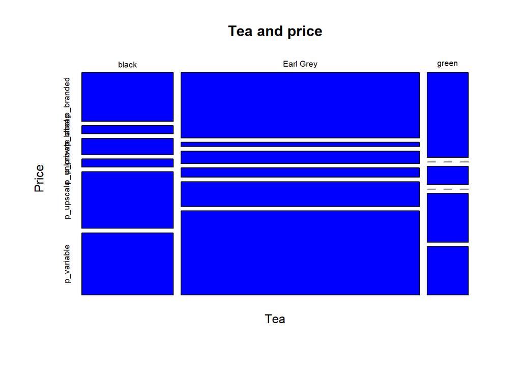

```r
# Summary plot
# Let's visualize part of the data
keep_columns_2<- c("price","Tea")
# Mosaic plot of couple variables
mosaicplot(table(tea[,colnames(tea) %in% keep_columns_2]), xlab='Tea', ylab='Price',main='Tea and price', col='blue')
```

```r
# Age has to be factorized by bins or removed --> remove
tea<-tea[!(colnames(tea) %in% 'age')]

# Multiple Correspondence Analysis (MCA)
# Could be set to vizualize also the correlation between variables and MCA principal dimension
res.mca<- MCA(tea, graph = FALSE)
# With so many variables the printed MCAfactor plots becomes harder to read.
# The object of MCA can be used for many different kind of visualizations -->
# Extract and save results for later use
var <- get_mca_var(res.mca)
var
```

```
## Multiple Correspondence Analysis Results for variables
##  ===================================================
##   Name       Description
## 1 "$coord"   "Coordinates for categories"
## 2 "$cos2"    "Cos2 for categories"
## 3 "$contrib" "contributions of categories"
```

```r
# Coordinates
head(var$coord)
```

```
##                    Dim 1        Dim 2       Dim 3       Dim 4       Dim 5
## breakfast      0.1818793  0.019872372 -0.10740185 -0.55341901 -0.09826250
## Not.breakfast -0.1678886 -0.018343728  0.09914017  0.51084831  0.09070384
## Not.tea time  -0.5562500  0.004261602  0.06242859  0.09798477  0.16970005
## tea time       0.4311760 -0.003303372 -0.04839139 -0.07595269 -0.13154265
## evening        0.2760859 -0.408578586  0.34396723  0.23142519 -0.26420301
## Not.evening   -0.1443495  0.213622307 -0.17984073 -0.12099896  0.13813660
```

```r
# Cos2: quality on the factore map
head(var$cos2)
```

```
##                    Dim 1        Dim 2       Dim 3       Dim 4       Dim 5
## breakfast     0.03053547 3.645334e-04 0.010647837 0.282713168 0.008912786
## Not.breakfast 0.03053547 3.645334e-04 0.010647837 0.282713168 0.008912786
## Not.tea time  0.23984168 1.407766e-05 0.003021007 0.007442207 0.022322794
## tea time      0.23984168 1.407766e-05 0.003021007 0.007442207 0.022322794
## evening       0.03985286 8.728150e-02 0.061859319 0.028002208 0.036496104
## Not.evening   0.03985286 8.728150e-02 0.061859319 0.028002208 0.036496104
```

```r
# Contributions to the principal components
head(var$contrib)
```

```
##                   Dim 1        Dim 2      Dim 3     Dim 4     Dim 5
## breakfast     0.5036943 0.0066328082 0.22530472 6.7101105 0.2373656
## Not.breakfast 0.4649486 0.0061225922 0.20797359 6.1939482 0.2191067
## Not.tea time  4.2859707 0.0002774934 0.06925046 0.1913584 0.6440432
## tea time      3.3222613 0.0002150984 0.05367935 0.1483310 0.4992288
## evening       0.8301633 2.0055059548 1.65293457 0.8393006 1.2274180
## Not.evening   0.4340448 1.0485640271 0.86422467 0.4388221 0.6417465
```

```r
# visualize MCA - many possibilites

# Eigenvalues/Variances
# In linear algebra, an eigenvector or characteristic vector of a linear transformation is a nonzero vector that changes at most by a scalar factor when that linear transformation is applied to it. The corresponding eigenvalue, often denoted by λ \lambda , is the factor by which the eigenvector is scaled.
# Geometrically, an eigenvector, corresponding to a real nonzero eigenvalue, points in a direction in which it is stretched by the transformation and the eigenvalue is the factor by which it is stretched. If the eigenvalue is negative, the direction is reversed.[1] Loosely speaking, in a multidimensional vector space, the eigenvector is not rotated.(wikipedia)

# get values
eig.val <- get_eigenvalue(res.mca)
# Dataframe contains also variance % and cumalative variance %. Those can be used to visualize how much of yhre variance is explained by it dimensions e.g. in histplot
head(eig.val)
```

```
##       eigenvalue variance.percent cumulative.variance.percent
## Dim.1 0.09006849         5.837772                    5.837772
## Dim.2 0.08165357         5.292361                   11.130133
## Dim.3 0.07021443         4.550936                   15.681069
## Dim.4 0.06259673         4.057196                   19.738264
## Dim.5 0.05578674         3.615807                   23.354071
## Dim.6 0.05345502         3.464677                   26.818748
```

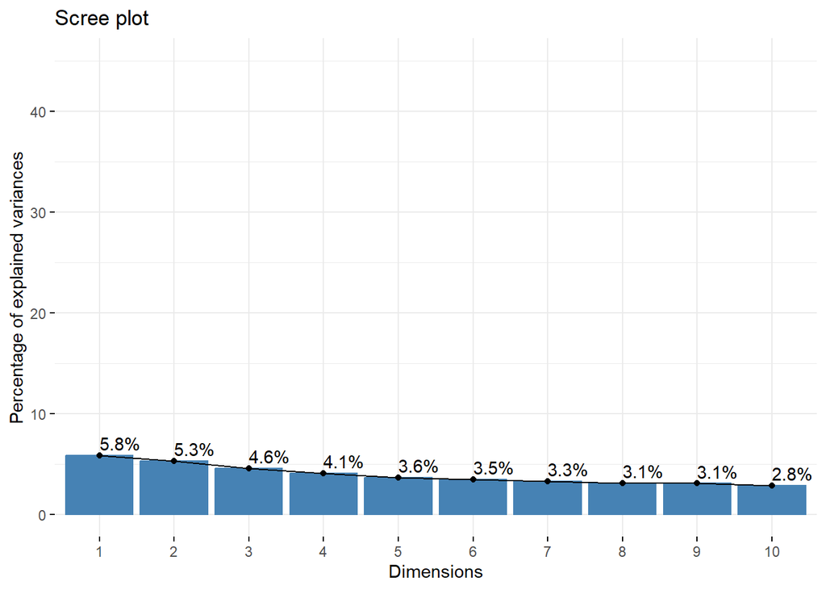

```r
# Build plot
fviz_screeplot(res.mca, addlabels = TRUE, ylim = c(0, 45))
```

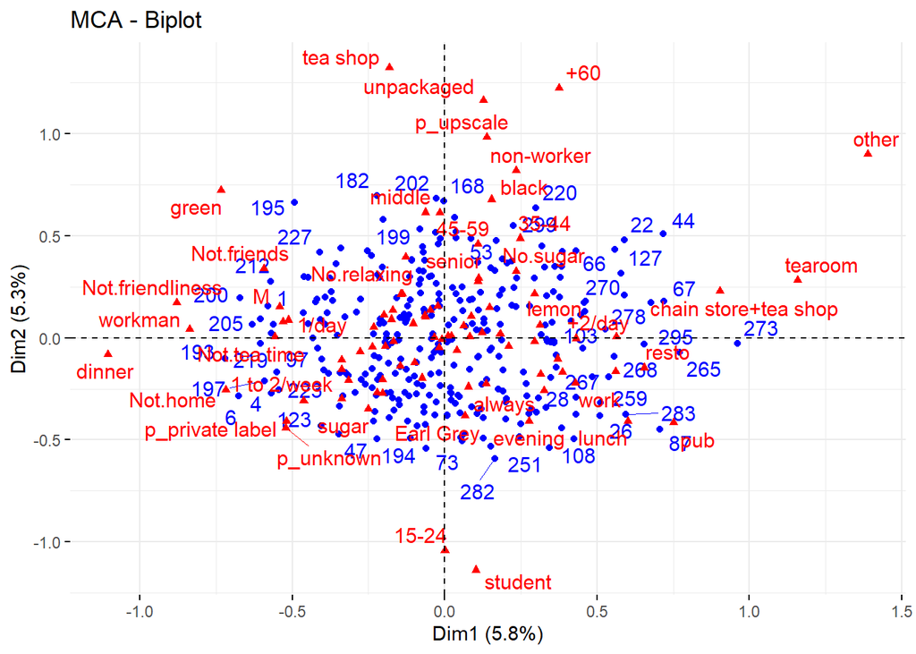

```r
# Biplot
# The plot shows a global pattern within the data. Rows (individuals) are represented by blue points and columns (variable categories) by red triangles.
# The distance between any row points or column points gives a measure of their similarity (or dissimilarity). Row points with similar profile are closed on the factor map. The same holds true for column points.
fviz_mca_biplot(res.mca,
               repel = TRUE,
               ggtheme = theme_minimal())
```

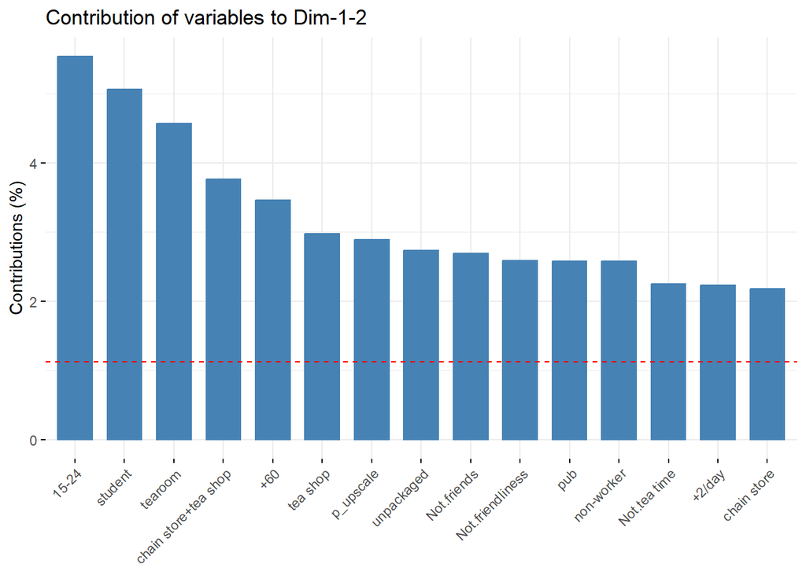

```r
# Contribution of variable categories to the dimensions 1-2
# The red dashed line on the graph indicates the expected average value, If the contributions were uniform.
fviz_contrib(res.mca, choice = "var", axes = 1:2, top = 15)
```

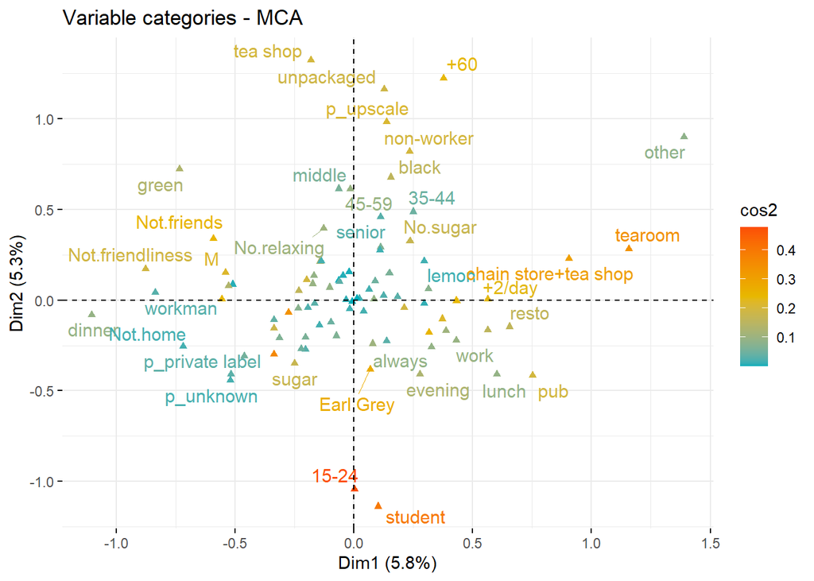

```r
# Cos2
# The quality of the representation is called the squared cosine (cos2), which measures the degree of association between variable categories and a particular axis.
# Color by cos2 values: quality on the factor map
fviz_mca_var(res.mca, col.var = "cos2",
             gradient.cols = c("#00AFBB", "#E7B800", "#FC4E07"),
             repel = TRUE, # Avoid text overlapping
             ggtheme = theme_minimal())
```

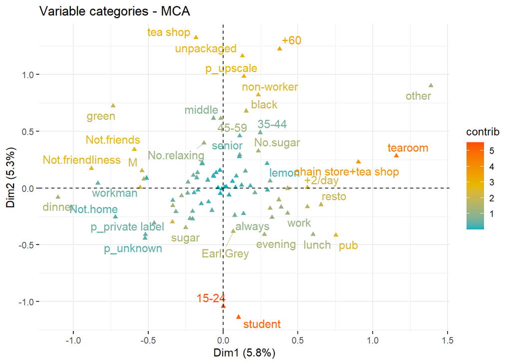

```r
# Contribution
# The plot above gives an idea of what pole of the dimensions the categories are actually contributing to.
# Color by contribution values: quality on the factor map
fviz_mca_var(res.mca, col.var = "contrib",
             gradient.cols = c("#00AFBB", "#E7B800", "#FC4E07"),
             repel = TRUE, # avoid text overlapping (slow)
             ggtheme = theme_minimal()
             )
```

```r
# From the plots we can read many things and make assumptions and maybe even conclusions, but also more test for that should be done. We can see that e.g tea shop, none working and older age seems to have positive influence to dim 2 where as student which positively correlates with age group 15-24 have negative influence to dim 2. Could this indicate that there are age and civil status related difference in tea drinking habits? Also location where tea is drinked seems to correlate with lunch tea consumption according dim 1. Could this indicates that workers like to drink their lunch tea typically in pub, chain store+ tea shop and tearoom rater than in home?
```